# Arbeiten mit DataFrames: local global warming...

## Mitteltemperatur für Klimanormalperioden

Der Bezugszeitraum für die Berechnung statistischer Kennwerte des Klimas ist die [Klimanormalperiode](https://de.wikipedia.org/wiki/Normalperiode). Die aktuelle Normalperiode ist 1991-2020. Man kommt bei Klimabeobachtungen nicht oft in den Genuss, vier Normalperioden miteinander vergleichen zu können. Bei der Säkularstation ist das möglich.

In `pandas` können wir mit Hilfe des datetime-`index` sehr komfortabel Zeiträume auswählen. `pandas` erkennt dabei normalerweise gut, was für Zeitelemente wir dabei meinen. Im folgenden Beispiel reicht die Angabe der Jahre:

```python
# Mitteltemperatur in Potsdam für Normalperiode 1991-2020
df.loc["1991":"2020"].temp.mean()
```

```
9.817713914164365
```

### Aufgabe: Vergleich der Normalperioden und "Special Feature" zu String-Formatierung

Berechne die Mitteltemperatur für die Klimanormalperioden 1901-1930, 1931-1060, 1961-1990 und 1991-2020.

- Welches war die wärmste Normalperiode?
- Welches die kälteste?
- Wie groß ist Differenz zwischen wärmster und kältester Normalperiode?
- Wie groß ist die Differenz zwischen der aktuellen und der vergangenen Normalperiode?

Kleines Extra für Eure Lösung: string formatting. Lernt, wie Ihr Zahlen und Zeichenketten effizient zu Strings zusammensetzen könnt. Wie haben ja schon gelernt, dass man strings mit dem `+`-Zeichen verketten kann. Aber es geht noch besser. Am Besten am Beispiel:

```python
# Strings einbetten
name = "Säkularstation"
print("Name der Station: %s" % name)
```

```
Name der Station: Säkularstation
```

```python
# Floats einbetten, hier gerundet auf zwei Dezimalstellen
lat = 52.3813
lon = 3.0622
print("Standort der %s: %.2f geogr. Länge, %.2f geogr. Breite." % (name, lon, lat))
```

```
Standort der Säkularstation: 3.06 geogr. Länge, 52.38 geogr. Breite.
```

```python
# Integer einbetten
print("Länge der Zeitreihe am Standort %s: %d Stunden" % (name, len(df)))
```

```
Länge der Zeitreihe am Standort Säkularstation: 1122010 Stunden
```

```python
# Datumsformat einbetten
# (das werden wir später nochmal ausführlich machen)
print("Erste Stunde in der Zeitreihe am Standort %s: %s Uhr UTC" % (name, df.index[0].strftime("%d. %B %Y, %H:%M") ) )
```

```
Erste Stunde in der Zeitreihe am Standort Säkularstation: 01. January 1893, 01:00 Uhr UTC
```

Versucht nun also die Antworten auf die obigen Fragen mit Hilfe der String-Formatierung via `print` "auszudrucken".

### Lösung

```python
avgT1901 = df["1901":"1930"].temp.mean()
avgT1931 = df["1931":"1960"].temp.mean()
avgT1961 = df["1961":"1990"].temp.mean()
avgT1991 = df["1991":"2020"].temp.mean()

print("Mitteltemperaturen der Klimanormalperioden:")
print("   1901-1930: %.1f °C(kälteste)" % avgT1901)
print("   1931-1960: %.1f °C" % avgT1931)
print("   1961-1990: %.1f °C" % avgT1961)
print("   1991-2020: %.1f °C (wärmste)" % avgT1991)
print()
print("Differenzen zwischen den Mittelwerten:")
print("   Wärmste NP (1991-2020) - kälteste NP (1901-1930): %.1f °C" % (avgT1991-avgT1901))
print("   avgT(1991-2020} - avgT(1961-1990): %.1f °C" % (avgT1991-avgT1961))
print("")
print("What do we want: climate justice! When do we want it: now!")
```

```
Mitteltemperaturen der Klimanormalperioden:
   1901-1930: 8.4 °C(kälteste)
   1931-1960: 8.7 °C
   1961-1990: 8.7 °C
   1991-2020: 9.8 °C (wärmste)

Differenzen zwischen den Mittelwerten:
   Wärmste NP (1991-2020) - kälteste NP (1901-1930): 1.4 °C
   avgT(1991-2020} - avgT(1961-1990): 1.1 °C

What do we want: climate justice! When do we want it: now!
```

### Nochmal die Abbildung: nun mit den Mittelwerten der Normalperioden

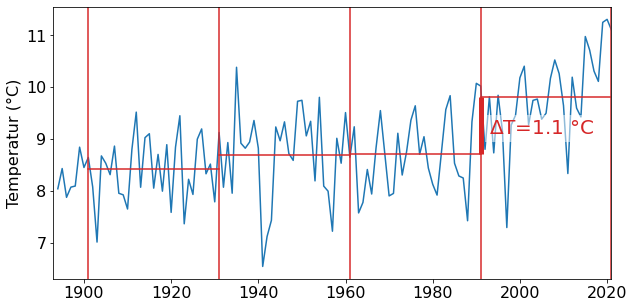

```python
plt.rcParams.update({'font.size': 16})

fig, axes = plt.subplots(nrows=1, ncols=1, figsize=(10,5))

plt.plot(dfa.index, dfa.temp, "-", color="tab:blue")
#plt.grid()
plt.ylabel("Temperatur (°C)")
#plt.title("Jahresmitteltemperatur, Säkularstation Potsdam")
plt.xlim(pd.to_datetime("1893-01-01"), pd.to_datetime("2021-01-01"))
# Grenzen der Normalperioden einzeichnen
plt.axvline(pd.to_datetime("1901-01-01"), ls="-", color="tab:red")
plt.axvline(pd.to_datetime("1931-01-01"), ls="-", color="tab:red")
plt.axvline(pd.to_datetime("1961-01-01"), ls="-", color="tab:red")
plt.axvline(pd.to_datetime("1991-01-01"), ls="-", color="tab:red")
plt.axvline(pd.to_datetime("2021-01-01"), ls="-", color="tab:red")
# T-Mittelwerte der Normalperioden
plt.plot([pd.to_datetime("1901-01-01"), pd.to_datetime("1930-12-31")], [avgT1901, avgT1901], color="tab:red")
plt.plot([pd.to_datetime("1931-01-01"), pd.to_datetime("1960-12-31")], [avgT1931, avgT1931], color="tab:red")
plt.plot([pd.to_datetime("1961-01-01"), pd.to_datetime("1990-12-31")], [avgT1961, avgT1961], color="tab:red")
plt.plot([pd.to_datetime("1991-01-01"), pd.to_datetime("2020-12-31")], [avgT1991, avgT1991], color="tab:red")
# Betonung der Differenz zwischen letzter und aktueller NP
plt.plot([pd.to_datetime("1991-01-01"), pd.to_datetime("1991-01-01")],
            [avgT1961, avgT1991], color="tab:red", lw=5, solid_capstyle="butt")
_ = plt.text(pd.to_datetime("1992-12-01"), 9.1, r"$\Delta$"+"T=%.1f °C" % (avgT1991-avgT1961),
         fontsize=20, color="tab:red", bbox=dict(facecolor='white', alpha=0.5, edgecolor='None'))
```

## Mittlere Tagesgänge

Ein weiteres der vielen beeindruckenden Features von `pandas` ist die `groupby`-Funktion. Sie erlaubt es uns, die Einträge des DataFrames nach bestimmten Merkmalen zu gruppieren und für diese Gruppen dann Funktionen anzuwenden. Wir nutzen diese Funktionalität, um mit einer einzigen Zeile den mittleren Tagesgang von Temperatur und relativer Luftfeuchte in Potsdam zu ermitteln. Jetzt wissen wir auch, warum wir die ganze Zeit die Spalte `rh` mitgeschleppt haben.

```python
# groupby zusammen mit der Stunde des Tages, die wir aus dem Zeitindex des DatFrame extrahieren
dfh = df.groupby(df.index.hour).mean()
```

```python
dfh
```

| datetime | temp | rh |
| --- | --- | --- |
| 0 | 7.143430 | 85.920234 |
| 1 | 6.851835 | 87.083679 |
| 2 | 6.576347 | 88.054951 |
| 3 | 6.338821 | 88.890505 |
| 4 | 6.138487 | 89.601656 |
| 5 | 6.063132 | 89.916130 |
| 6 | 6.258181 | 89.335565 |
| 7 | 6.885615 | 86.928044 |
| 8 | 7.807471 | 83.264165 |
| 9 | 8.875138 | 78.965712 |
| 10 | 9.926198 | 74.557015 |
| 11 | 10.828393 | 70.664200 |
| 12 | 11.520239 | 67.678980 |
| 13 | 11.992088 | 65.714267 |
| 14 | 12.224182 | 64.859829 |
| 15 | 12.144740 | 65.099444 |
| 16 | 11.780729 | 66.669005 |
| 17 | 11.169504 | 69.218995 |
| 18 | 10.405378 | 72.444813 |
| 19 | 9.593606 | 75.843658 |
| 20 | 8.838171 | 78.830695 |
| 21 | 8.285211 | 81.176684 |
| 22 | 7.838021 | 83.104471 |
| 23 | 7.468984 | 84.628128 |

Schöner sieht das natürlich in einer Abbildung aus. Wir wissen aber jetzt schon, dass wir Schwierigkeiten kriegen, wenn wir die Variable `temp` und `relhum` auf eine Achse plotten, da ihre Wertebereiche zu unterschiedlich sind (siehe Tabelle). Darum lernen wir bei dieser Gelegenheit die Sekundärachse kennen.

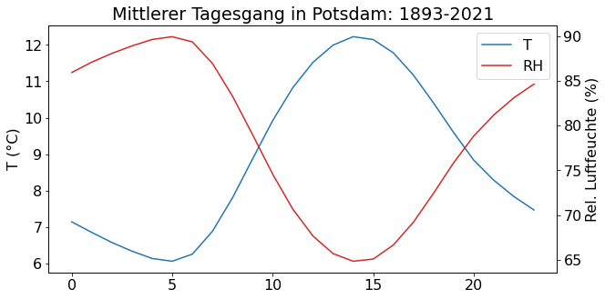

```python
fig, axes = plt.subplots(nrows=1, ncols=1, figsize=(10,5))
tpl = plt.plot(dfh.index, dfh.temp, "-", color="tab:blue", label="T")
plt.ylabel("T (°C)")
# Hier kommt die Sekundärachse ins Spiel
plt.twinx()
rhpl = plt.plot(dfh.index, dfh.rh, "-", color="tab:red", label="RH")
plt.ylabel("Rel. Luftfeuchte (%)")
plt.title("Mittlerer Tagesgang in Potsdam: 1893-2021")
_ = plt.legend(handles=[tpl[0], rhpl[0]])
```

### Aufgabe

Kleine Auffrischung aus der Angewandten Klimatologie im Bachelor: Erkläre Deinen Nachbar:innen, den Verlauf der beiden Kurven. Warum fällt das Temperaturmaximum nicht mit dem mittleren Sonnenhöchststand zusammen? Wie lässt sich der Verlauf der relativen Luftfeuchte erklären.

### Lösung

Die Temperatur der Erdoberfläche steigt, wenn die Nettostrahlung positiv ist und sinkt, wenn sie negativ ist. Die Nettostrahlung wiederum ergibt sich aus der Differenz aus kurzwelliger Strahlungseinnahme (Globalstrahlung abzüglich Albedo) und effektiver langwelliger Ausstrahlung (Ausstrahlung abzüglich atmosphärischer Gegenstrahlung). Die Nettostrahlung ist positiv auch über den Sonnenhöchststand hinaus, wird im Laufe des Nachmittags negativ und erst eine Weile nach Sonnenaufgang wieder positiv. Desweiteren braucht es eine Weile, bis sich die Temperaturdynamik von der Oberfläche bis in 2 m Messhöhe fortsetzt.

Die Dynamik der relativen Luftfeuchte

$RH = \frac{e}{E(T)}$

ist maßgeblich von der Temperatur getrieben, da der Sättigungdampfdruck $E(T)$ gemäß Magnus-Formel exponentiell von der Lufttemperatur $T$ abhängt. Die Dynamik der tatsächlichen Luftfuechte (z.B. ausgedrückt als Dampfdruck $e$) geht darin fast unter.

## Mögliche Vertiefungen in der Coding-Werkstatt

1. Ermittle die Differenz der Mitteltemperatur zwischen den Normalperioden 1961-1990 und 1991-2020 für die Bergwetterwarte Hohenpeißenberg. Wo ist die Differenz größer: in Potsdam oder am Hohenpeißenberg?

   Die Daten findet Ihr auf dem opendata-Server des DWD ([Link](https://opendata.dwd.de/climate_environment/CDC/observations_germany/climate/hourly/air_temperature/historical/)). Ihr müsst in dem opendata-Verzeichnis allerdings erstmal rausfinden, in welcher Datei die Daten der Station Hohenpeißenberg liegen...
1. Berechne als zusätzliche Spalte des DataFrame `df` den Dampfdruck (in hPa). Mache Dir dazu die Definition der relativen Luftfeuchte zunutze. Verwende in erster Näherung die Magnusformel über ebenen Wasserflächen:

   $e = 6.112 * exp(\frac{17.61 * T}{243.12 + T})$

   Stelle nun den mittleren Tagesgang der Temperatur und des Dampfdrucks dar!
1. Etwas schwerer...stelle den mittleren Tagesgang der Temperatur in den Monaten Dez-Feb im Vergleich zu den Monaten Jun-Aug dar. Was fällt auf?